# R Visualizaciones Intermedio - EDA

## Objetivo:

Veremos como utilizar las visualizaciones para hacer Analisis Exploratorio de Datos (EDA)

### Visualizando distribuciones.

- Si una variable es categórica, en general se utiliza un gráfico de barras que muestra el conteo de cada valor posible de la variable categórica (utiliza la stat: count)
- Si la variable es contínua, entonces para ver distribución combiene utilizar un histograma. En este caso se divide la variable en “franjas” y se realiza un conteo: se utiliza la stat_bin. En el caso de histograma conviene indicar el “ancho de las bandas” *binwidth* Puedes calcular esto manualmente combinando dplyr::count() y ggplot2::cut_width(). Siempre deberías explorar una variedad de distintas medidas para el ancho del intervalo cuando estés trabajando con histogramas, pues distintas medidas pueden revelar diferentes patrones. Para sobreponer múltiples distribuciones contínuas en la misma gráfica, se recomienda usar geom_freqpoly().

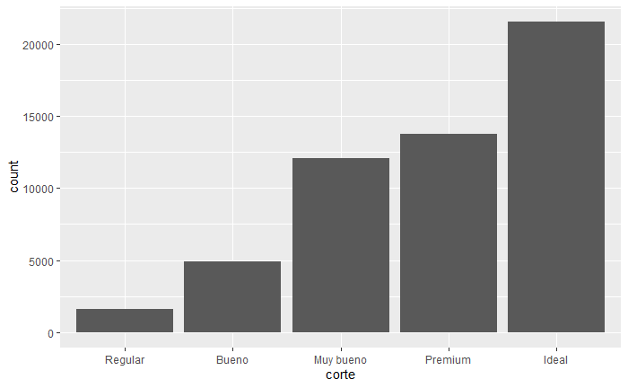

```r
pequenos <- diamantes %>%
  filter(quilate < 3)   # 1 variable histograma

ggplot(data = diamantes) +
  geom_bar(mapping = aes(x = corte))
```

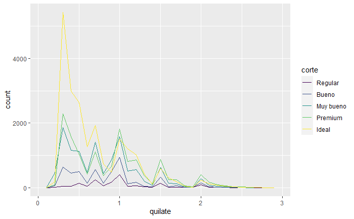

```r
ggplot(data = pequenos, mapping = aes(x = quilate, colour = corte)) +
  geom_freqpoly(binwidth = 0.1)
```

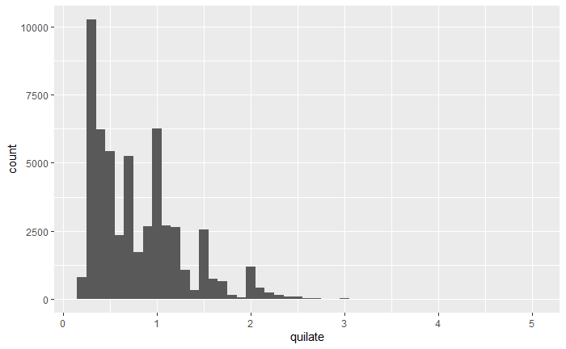

```r
ggplot(data = diamantes) +
  geom_histogram(mapping = aes(x = quilate), binwidth = 0.1) #variar binwidth al achicar más detalle
```

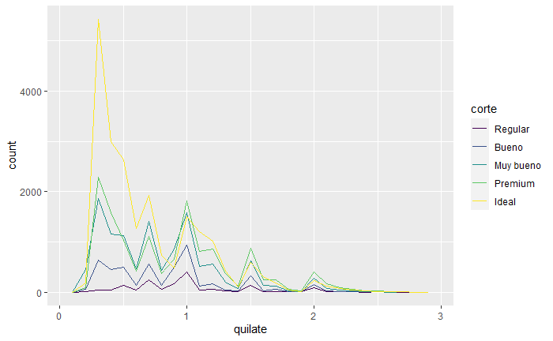

```r
ggplot(data = pequenos, mapping = aes(x = quilate, colour = corte)) +
  geom_freqpoly(binwidth = 0.1)
```

**Las agrupaciones de valores similares sugieren que ciertos subgrupos existen en tus datos**

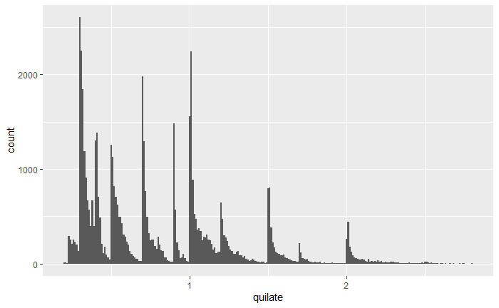

```r
ggplot(data = pequenos, mapping = aes(x = quilate)) +
  geom_histogram(binwidth = 0.01)
```

## Valores Inusuales o atípicos (*outliers*)

Son difíciles de hallar con un histograma. Se podría aislar las partes con menos valores, y estudiarlas. Otra forma es con puntos, pero si son muchas las observaciones, el gráfico es muy sucio.

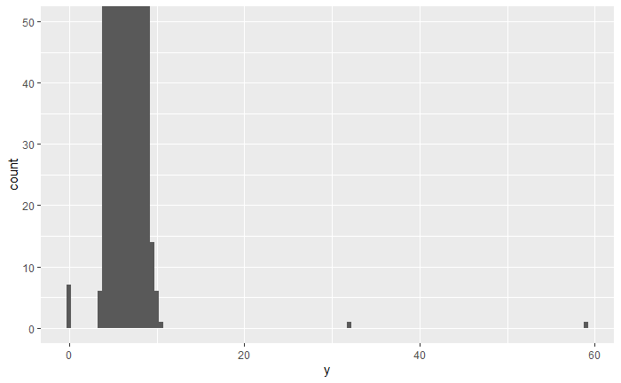

```r
ggplot(diamantes) +
  geom_histogram(mapping = aes(x = y), binwidth = 0.5) +
  coord_cartesian(ylim = c(0, 50)) # también existe xlim (cuando se quiere "hacer zoom" en eje x)
```

Es un buen hábito repetir tu análisis con y sin los valores inusuales. Si tienen un efecto mínimo en los resultados y no puedes descubrir por qué están en los datos, es razonable reemplazarlos con valores ausentes y seguir adelante con tu análisis. Sin embargo, si tienen un efecto sustancial en tus resultados, no deberías ignorarlos sin justificación.

##Valores faltantes

Si los valores inusuales se eliminan puedes quedar con pocos datos, y nada te dice si las demas mediciones (columnas) tenían datos confiables y los estas desperdiciando. Una alternativa conveniente cambiar esos valores como valores faltantes NA. Se puede hacer con dplyr:: mutate(ifelse(condicion, TRUE, FALSE)) y en casos más complejos con case_when().  
ggplot2 emite mensaje cuando encuentra valores faltantes en los datos que se grafican:

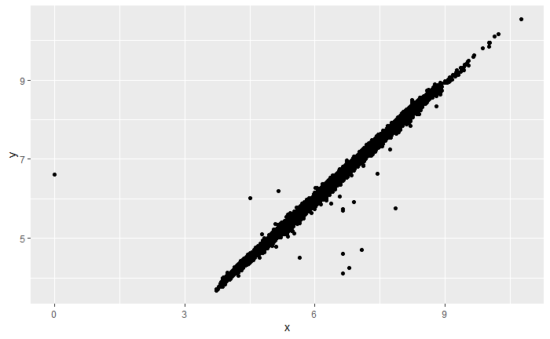

```r
diamantes %>%
  mutate(y = ifelse(y < 3 | y > 20, NA, y)) %>%
  ggplot(mapping = aes(x = x, y = y)) +
  geom_point() #Mensaje  Removed 9 rows containing missing values (geom_point)
```

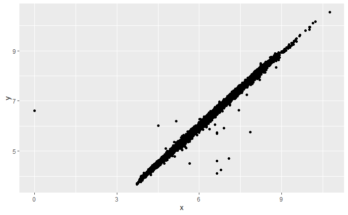

```r
# Para eliminar el mensaje
diamantes %>%
  mutate(y = ifelse(y < 3 | y > 20, NA, y)) %>%
  ggplot(mapping = aes(x = x, y = y)) +
  geom_point(na.rm = TRUE)
```

```r
summary(select(diamantes, x, y, z))
```

```
       x                y                z
 Min.   : 0.000   Min.   : 0.000   Min.   : 0.000
 1st Qu.: 4.710   1st Qu.: 4.720   1st Qu.: 2.910
 Median : 5.700   Median : 5.710   Median : 3.530
 Mean   : 5.731   Mean   : 5.735   Mean   : 3.539
 3rd Qu.: 6.540   3rd Qu.: 6.540   3rd Qu.: 4.040
 Max.   :10.740   Max.   :58.900   Max.   :31.800
```

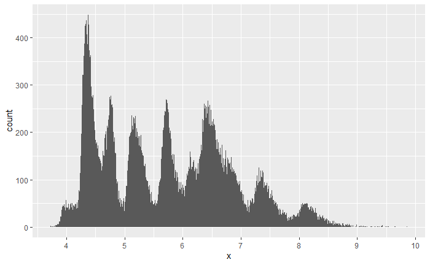

```r
filter(diamantes, x > 0, x < 10) %>%
  ggplot() +
  geom_histogram(mapping = aes(x = x), binwidth = 0.01) +
  scale_x_continuous(breaks = 1:10)
```

## Covariacion

La covariación es la tendencia de los valores de dos o más variables a variar simultáneamente de una manera relacionada. La mejor manera de reconocer que existe covariación en tus datos es visualizar la relación entre dos o más variables.

### Una variable categórica y una variable continua

Una posibilidad es con freqpoly dividiendo por las lineas por corte, Pero si hay muchos casos de una determinada categoría se desvirtua. En esos casos conviene que el eje y sea la densidad (donde suma a 1) y no la cantidad

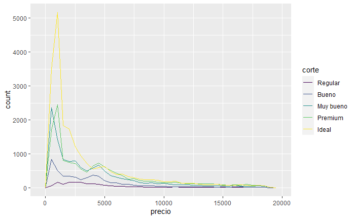

```r
ggplot(data = diamantes, mapping = aes(x = precio)) +
  geom_freqpoly(mapping = aes(colour = corte), binwidth = 500)
```

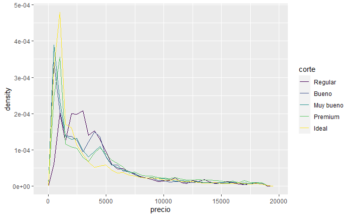

```r
ggplot(data = diamantes, mapping = aes(x = precio, y = ..density..)) +
  geom_freqpoly(mapping = aes(colour = corte), binwidth = 500)
```

Otra alternativa es con boxplot. En este caso, nos muestra que es más alto el precio para los cortes regulares, y más bajo para los ideales.

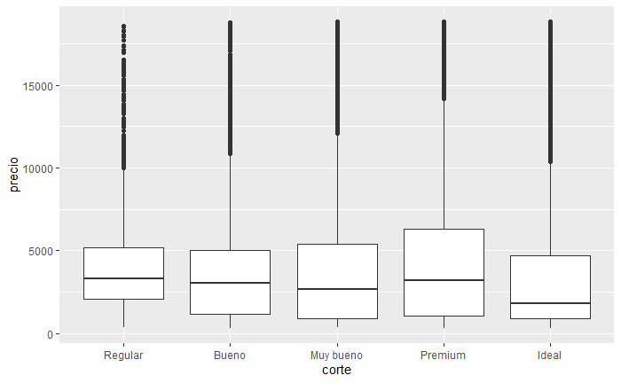

```r
diamantes %>%
  ggplot(aes(x = corte, y = precio)) +
  geom_boxplot()
```

### 2 variables categóricas.

En general es limitado los geoms que se pueden utilizar en este caso, porque se van a suporponer valores (cosa que en general no pasa con una variable contínua). Para este caso el geom_count() es una buena opcion.

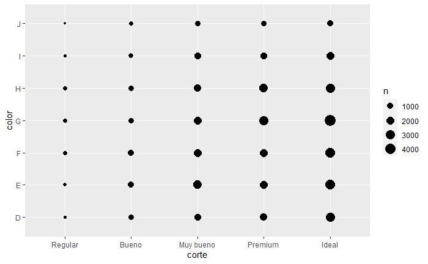

```r
ggplot(data = diamantes) +
  geom_count(mapping = aes(x = corte, y = color))
```

Otra estrategia es calcular el recuento con dplyr, y después visualizar con geom_tile() y adaptar la estética de relleno (fill):

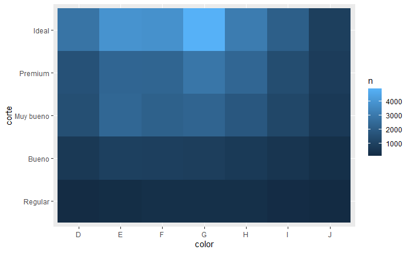

```r
diamantes %>%
  count(color, corte) %>%
  ggplot(mapping = aes(x = color, y = corte)) +
    geom_tile(mapping = aes(fill = n))
```

### Dos variables contínuas:

En este caso se pueden utilizar geom_point, pero a veces resulta muy pesado para verlo: en ese caso se puede usar la transparencia para que no sature tanto.

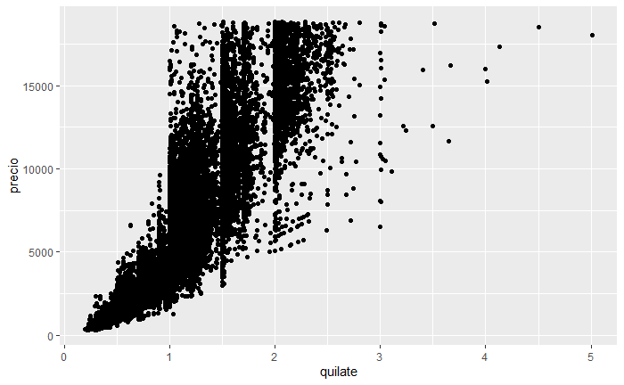

```r
ggplot(data = diamantes) +
  geom_point(mapping = aes(x = quilate, y = precio))
```

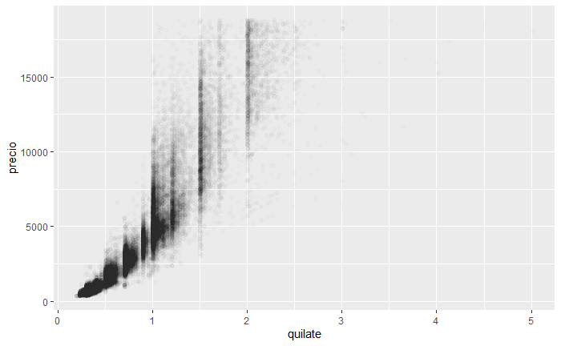

```r
ggplot(data = diamantes) +
  geom_point(mapping = aes(x = quilate, y = precio), alpha = 1 / 100)
```

Otra solucion es modificar el parámetro bin. Hasta ahora hicimos bin en una sola dirección con geom_histogram y geom_freqpoly. Ahora usaremos con 2 dimensiones: usando geom_bin2d o geom_hex

geom_bin2d() y geom_hex() dividen el plano cartesiano en unidades o contenedores bidimensionales y luego usan un color de relleno para mostrar cuántos puntos pueden ser clasificados en cada contenedor geom_bin2d() crea unidades rectangulares. geom_hex() crea unidades hexagonales (para usar geom_hex se necesitará instalar el paquete hexbin).

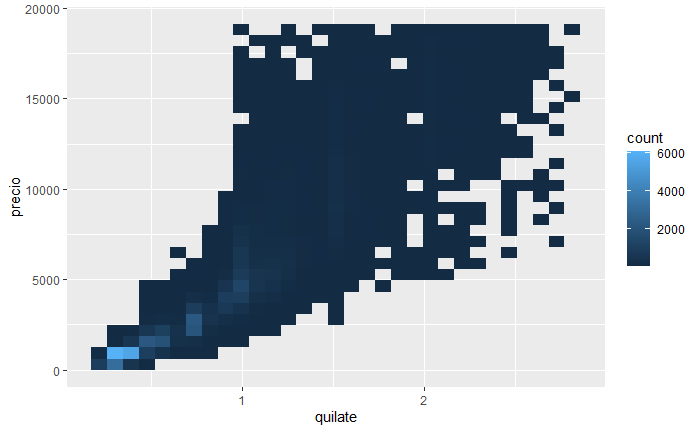

```r
ggplot(data = pequenos) +
  geom_bin2d(mapping = aes(x = quilate, y = precio))
```

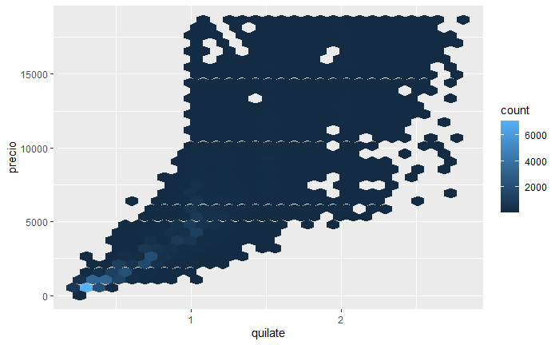

```r
library(hexbin)
ggplot(data = pequenos) +
  geom_hex(mapping = aes(x = quilate, y = precio))
```

Otra solucion es utilizar boxplots, pero haciendo previamente una segmentacion de una variable continua. cut_width(x, width) divide la variable x en intervalos de ancho width. Los diagramas así parecen muy similares sin importar la cantidad de casos. Para demostrar la cantidad de casos que representa cada caja, se puede usar usando también varwidth = TRUE… o también usando cut_number

```r
pequenos %>%
  count(quilate)
ggplot(data = pequenos, mapping = aes(x = quilate, y = precio)) +
  geom_boxplot(mapping = aes(group = cut_width(quilate, 0.2)))

ggplot(data = pequenos, mapping = aes(x = quilate, y = precio)) +
  geom_boxplot(mapping = aes(group = cut_width(quilate, 0.2)), varwidth = TRUE)

#Otra solución es mostrar aproximadamente el mismo número de datos en cada intervalo o unidad. Esto puedes lograrlo con cut_number():
ggplot(data = pequenos, mapping = aes(x = quilate, y = precio)) +
  geom_boxplot(mapping = aes(group = cut_number(quilate, 20)))
```

[output not shown]

## Relacion geometria, stat

Las siguiente tabla contienen los pares entre geometrías y estadísticos que se usan en conjunto.

[output not shown]

Tabla: Geometrías y estadísticos complementarios

Los nombres tienen a ser similares, por ejemplo `geom_smooth()` y `stat_smooth()`, aunque hay casos como `geom_bar()` y `stat_count()`.

La mayoría de las geometrías usa por defecto el estadístico que le corresponde en la tabla anterior. Recíprocamente, la mayoría de los estadísticos usan por defecto la geometría que le corresponde en la tabla anterior.

Las siguientes tablas contienen las geometrías y estadísticos en [ggplot2](https://ggplot2.tidyverse.org/reference/).

| geometría | estadístico por defecto | documentación conjunta |
| --- | --- | --- |
| `geom_abline()` |  |  |
| `geom_hline()` |  |  |
| `geom_vline()` |  |  |
| `geom_bar()` | `stat_count()` | x |
| `geom_col()` |  |  |
| `geom_bin2d()` | `stat_bin_2d()` | x |
| `geom_blank()` |  |  |
| `geom_boxplot()` | `stat_boxplot()` | x |
| `geom_countour()` | `stat_countour()` | x |
| `geom_count()` | `stat_sum()` | x |
| `geom_density()` | `stat_density()` | x |
| `geom_density_2d()` | `stat_density_2d()` | x |
| `geom_dotplot()` |  |  |
| `geom_errorbarh()` |  |  |
| `geom_hex()` | `stat_hex()` | x |
| `geom_freqpoly()` | `stat_bin()` | x |
| `geom_histogram()` | `stat_bin()` | x |
| `geom_crossbar()` |  |  |
| `geom_errorbar()` |  |  |
| `geom_linerange()` |  |  |
| `geom_pointrange()` |  |  |
| `geom_map()` |  |  |
| `geom_point()` |  |  |
| `geom_map()` |  |  |
| `geom_path()` |  |  |
| `geom_line()` |  |  |
| `geom_step()` |  |  |
| `geom_point()` |  |  |
| `geom_polygon()` |  |  |
| `geom_qq_line()` | `stat_qq_line()` | x |
| `geom_qq()` | `stat_qq()` | x |
| `geom_quantile()` | `stat_quantile()` | x |
| `geom_ribbon()` |  |  |
| `geom_area()` |  |  |
| `geom_rug()` |  |  |
| `geom_smooth()` | `stat_smooth()` | x |
| `geom_spoke()` |  |  |
| `geom_label()` |  |  |
| `geom_text()` |  |  |
| `geom_raster()` |  |  |
| `geom_rect()` |  |  |
| `geom_tile()` |  |  |
| `geom_violin()` | `stat_ydensity()` | x |
| `geom_sf()` | `stat_sf()` | x |

Tabla: ggplot2 capas de geometrías y sus estadísticos por defecto.

| estadístico | geometría por defecto | documentación conjunta |
| --- | --- | --- |
| `stat_ecdf()` | `geom_step()` |  |
| `stat_ellipse()` | `geom_path()` |  |
| `stat_function()` | `geom_path()` |  |
| `stat_identity()` | `geom_point()` |  |
| `stat_summary_2d()` | `geom_tile()` |  |
| `stat_summary_hex()` | `geom_hex()` |  |
| `stat_summary_bin()` | `geom_pointrange()` |  |
| `stat_summary()` | `geom_pointrange()` |  |
| `stat_unique()` | `geom_point()` |  |
| `stat_count()` | `geom_bar()` | x |
| `stat_bin_2d()` | `geom_tile()` | x |
| `stat_boxplot()` | `geom_boxplot()` | x |
| `stat_countour()` | `geom_contour()` | x |
| `stat_sum()` | `geom_point()` | x |
| `stat_density()` | `geom_area()` | x |
| `stat_density_2d()` | `geom_density_2d()` | x |
| `stat_bin_hex()` | `geom_hex()` | x |
| `stat_bin()` | `geom_bar()` | x |
| `stat_qq_line()` | `geom_path()` | x |
| `stat_qq()` | `geom_point()` | x |
| `stat_quantile()` | `geom_quantile()` | x |
| `stat_smooth()` | `geom_smooth()` | x |
| `stat_ydensity()` | `geom_violin()` | x |
| `stat_sf()` | `geom_rect()` | x |

Tabla: ggplot2 capas de estadísticos y sus geometrías por defecto.